# project_raport slides

## Optymalizacja kosztów podróży z wykorzystaniem algorytmu symulowanego wyżarzania.

## na przykładzie - Volkswagen Transporter t4

### Dominik Tomalczyk

### Dawid Woźniak

### Niezbędne importy

```python
import numpy as np
import matplotlib.pyplot as plt
from IPython.display import Image
import timeit
```

```python
import src.data_structures as ds
import src.utils as utils
from src.sa_algorithm import init_solution,simulated_annealing
from src.sa_algorithm import new_solution
from src.visualization import plot_random_stations
from src.visualization import plot_score, plot_solution
```

Parametry niezbędne do obliczeń zaczerpnięte ze specyfikacji samochodu:

- Pojemność baku - 80l
- średnie spalanie /100km - 7.3l

[figure not shown]

```python
Image(filename='car.jpg',width = 600, height = 300)
```

## Definicje niezbędnych stałych

```python
TANK_CAPACITY = 80
FUEL_CONSUM = 7.3

# Tyle możemy maksymalnie zjechać z trasy do stacji.
MAX_EXTRA_ROUTE = 50
# Przyjmujemy trasę o długości 5000 km.
END_POINT = 5000
# Przyjmujemy że na początku trasy w baku mamy 30 litrów paliwa.
FUEL_START = 30
```

## Sąsiedztwo

Sąsiedztwo otoczenia zdefiniowaliśmy na dwa sposoby. W głównej funkcji za pomocą parametru prawdopodobieństwa ustalamy z jakim prawdopodobieństwem znajdujemy nowe rozwiązanie w danym sąsiedztwie.

- Sąsiedztwo 1: Zmieniamy ilość tankowanego paliwa na stacjach
- Sąsiedztwo 2: Zmieniamy stację i ilość

Oba sąsiedztwa są 'zabezpieczone' tzn. stacja jest osiągalna z warunków problemu a ilości zatankowanego paliwa wystarczą na dojechanie do kolejnej stacji.

Pierwszy przykład działania algorytmu dla losowo wygenerowanych stacji.

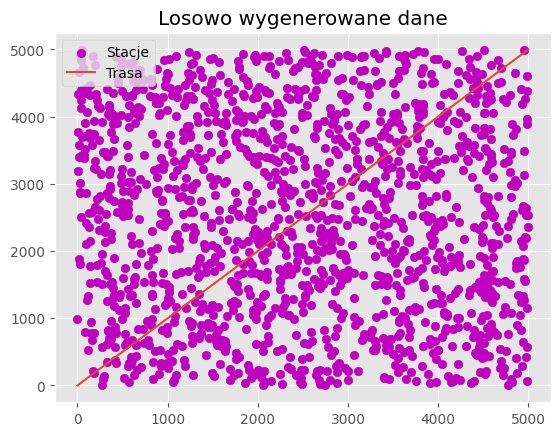

```python
# 1500 losowo wygenerowanych stacji
stations, cords = utils.random_station_generator(1500,
                            END_POINT,price_range=(7,10))

plot_random_stations(END_POINT, cords)
```

Wygenerowane powyżej stacje rozpatrujemy w algorytmie.

```python
car = ds.Car(TANK_CAPACITY, FUEL_CONSUM, 0, FUEL_START)
init_s = init_solution(car, END_POINT, MAX_EXTRA_ROUTE, stations)

print("Stacje wybrane podczas inicjalizacji rozwiązania:")
for station in init_s.get_solution():
    print(station)
print("\nWartość funkcji celu w pierwszym rozwiązaniu:"
      ,round(init_s.solution_value(), 2), )
```

[output not shown]

Wizualizacja wyniku otrzymanego jako rozwiązanie inicjujące:

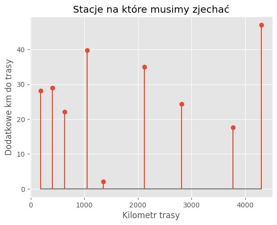

```python
plot_solution(init_s)
```

Przechodzimy do wywołania głównej funkcji realizującej algorytm. Nowe argumenty jakie wprowadzamy:

- Parametr T = 2000
- $\alpha$ = 0.95
- Maksymalna ilość iteracji = 10000
- Z prawdopodobieństwem 0.7 przyjmujemy sąsiedztwo zmiana stacji i ilości

```python
# W zmiennej lst_of_scores przechowujemy historie funkcji celu
best_solution, lst_of_scores, iters,worse = simulated_annealing(
                        new_solution,
                        init_s, stations, END_POINT, MAX_EXTRA_ROUTE
                        ,0.7, 2000, 0.95, 10000)
```

### Wizualizacja zmian funkcji celu w algorytmie

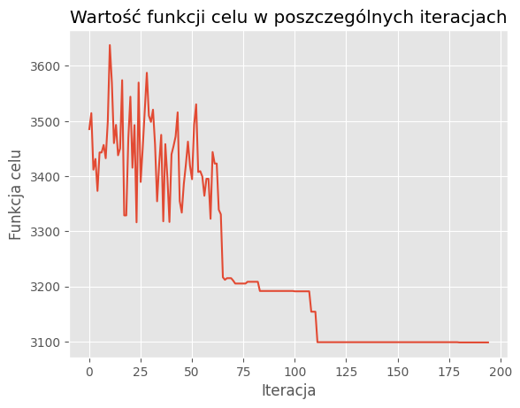

```python
plot_score(lst_of_scores, iters)
```

## Analiza otrzymanego wyniku

```python
print("\nNajlepsze otrzymane rozwiązanie:"
      ,round(best_solution.solution_value(), 2), )
print("Początkowe rozwiązanie:", round(init_s.solution_value(), 2), )
print("Liczba wykonanych iteracji:",iters )
print("Liczba zamian na gorsze rozwiązanie:",worse )
```

```
Najlepsze otrzymane rozwiązanie: 3098.59
Początkowe rozwiązanie: 3485.38
Liczba wykonanych iteracji: 194
Liczba zamian na gorsze rozwiązanie: 34
```

## O czym mówi najlepsze rozwiązanie?

```python
print("Wartość funkcji celu:",round(best_solution.solution_value(), 2))
print("Koszt zatankowanego paliwa:",round(best_solution.get_cost_of_solution(), 2))
print("Wartość funkcji kary:", round(best_solution.get_penalty(), 2))
print("Bilans start/koniec paliwa", best_solution.fuel_difference)
```

```
Wartość funkcji celu: 3098.59
Koszt zatankowanego paliwa: 2794.41
Wartość funkcji kary: 95.87
Bilans start/koniec paliwa -27.28
```

Wizualizacja wyniku otrzymanego jako rozwiązanie najlepsze:

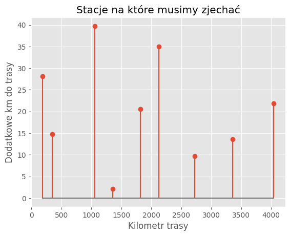

```python
plot_solution(best_solution)
```

## Czy mogliśmy uzyskać lepsze rozwiązanie? Sprawdźmy otrzymane wyniki w zależności od przyjęcia różnych wartości parametru P

```python
P_values = [0, 0.1, 0.3, 0.5, 0.7, 0.9, 1]
scores = []
for elem in P_values:
    best_solution, lst_of_scores, iters,worse = simulated_annealing(
                        new_solution,
                        init_s, stations, END_POINT, MAX_EXTRA_ROUTE
                        ,elem, 2000, 0.95, 10000)
    scores.append(round(best_solution.solution_value(), 2))
```

```python
for p,s in zip(P_values, scores):
    print(f'Parametr P: {p:.1f} \nWartość funkcji celu: {s}\n')
```

```
Parametr P: 0.0
Wartość funkcji celu: 3257.38

Parametr P: 0.1
Wartość funkcji celu: 3206.27

Parametr P: 0.3
Wartość funkcji celu: 3234.81

Parametr P: 0.5
Wartość funkcji celu: 3170.56

Parametr P: 0.7
Wartość funkcji celu: 3084.19

Parametr P: 0.9
Wartość funkcji celu: 3123.0

Parametr P: 1.0
Wartość funkcji celu: 3110.35
```

```python
print(f'Najlepsze rozwiązanie otrzymaliśmy dla parametru P równego {P_values[np.argmin(scores)]}. Nie ma jednak reguły.')
```

```
Najlepsze rozwiązanie otrzymaliśmy dla parametru P równego 0.7. Nie ma jednak reguły.
```

### Jednak nie jest to jedyny parametr, który możemy zmieniać. Zwiększmy teraz parametry T oraz $\alpha$.

- T = 20000
- $\alpha$ = 0.99

```python
best_solution, lst_of_scores, iters,worse = simulated_annealing(
                        new_solution,
                        init_s, stations, END_POINT, MAX_EXTRA_ROUTE
                        ,0.7, 20000, 0.99, 10000)
```

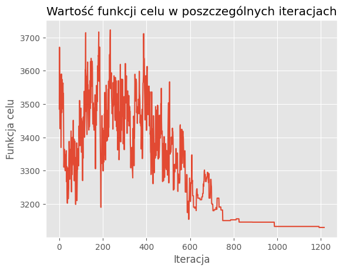

```python
plot_score(lst_of_scores, iters)
```

```python
print("\nNajlepsze otrzymane rozwiązanie:"
      ,round(best_solution.solution_value(), 2))
print("Początkowe rozwiązanie:", round(init_s.solution_value(), 2))
print("Liczba wykonanych iteracji:",iters )
print("Liczba zamian na gorsze rozwiązanie:",worse )
```

```
Najlepsze otrzymane rozwiązanie: 3129.78
Początkowe rozwiązanie: 3485.38
Liczba wykonanych iteracji: 1215
Liczba zamian na gorsze rozwiązanie: 299
```

### Zbadajmy znów zachowanie algorytmu dla różnych wartości parametru P

```python
P_values = [0, 0.1, 0.3, 0.5, 0.7, 0.9, 1]
scores = []
for elem in P_values:
    best_solution, lst_of_scores, iters,worse = simulated_annealing(
                        new_solution,
                        init_s, stations, END_POINT, MAX_EXTRA_ROUTE
                        ,elem, 20000, 0.99, 10000)
    scores.append(round(best_solution.solution_value(), 2))
```

```python
for p,s in zip(P_values, scores):
    print(f'Parametr P: {p:.1f} \nWartość funkcji celu: {s}\n')
```

```
Parametr P: 0.0
Wartość funkcji celu: 3232.41

Parametr P: 0.1
Wartość funkcji celu: 3147.53

Parametr P: 0.3
Wartość funkcji celu: 3085.52

Parametr P: 0.5
Wartość funkcji celu: 3133.56

Parametr P: 0.7
Wartość funkcji celu: 3096.23

Parametr P: 0.9
Wartość funkcji celu: 3070.96

Parametr P: 1.0
Wartość funkcji celu: 3072.17
```

```python
print(f'Najlepsze rozwiązanie otrzymaliśmy dla parametru P równego {P_values[np.argmin(scores)]}. Nie ma tutaj jednak reguły')
```

```
Najlepsze rozwiązanie otrzymaliśmy dla parametru P równego 0.9. Nie ma tutaj jednak reguły
```

Po zwiększeniu parametru T oraz $\alpha$ otrzymaliśmy lepsze wyniki. Można z tego wnioskować że im więcej iteracji, tym większa szansa na znalezienie lepszego rozwiązania.

Dla tych wartości parametrów porównamy przebiegi funkcji celu.

Przebiegi funkcji celu.

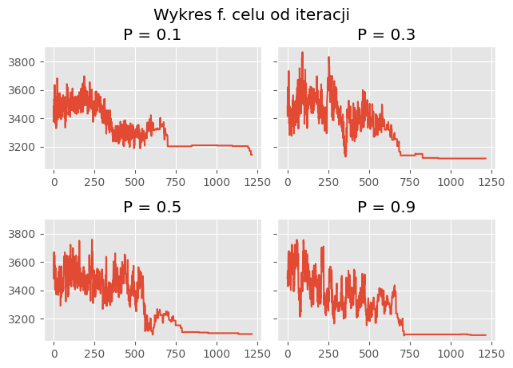

```python
plot_proba()
```

## Jak zachowa się algorytm po rozpoczęciu działania od najlepszego rozwiązania?

Rozpoczynamy od znalezienia najlepszego rozwiązania po 1000 iteracjach.

```python
best_solution, _, _,_ = simulated_annealing(
                        new_solution,
                        init_s, stations, END_POINT, MAX_EXTRA_ROUTE
                        ,0.7, 20000, 0.99, 1000)
print(best_solution.solution_value())
```

```
2891.44
```

## Następnie wywołujemy algorytm rozpoczynając od tego rozwiązania:

```python
new_best, _, _,_ = simulated_annealing(
                        new_solution,
                        best_solution, stations, END_POINT, MAX_EXTRA_ROUTE
                        ,0.7, 20000, 0.99, 1000)
print(new_best.solution_value())
```

```
2884.76
```

Jak widać w kolejnym wywołaniu udało nam się znaleźć lepsze rozwiązanie, jednak tutaj nie jest to gwarantowane. Mamy pewność że nie znajdziemy gorszego rozwiązania. Jednak jeśli pierwsze rozwiązanie było znalezione po dużej ilości iteracji ciężko nam będzie je już poprawić. Jest to kolejny przykład na to, że im więcej iteracji dopuścimy tym większa szansa na znalezienie lepszego rozwiązania.

## Zależność wyniku od rozwiązania początkowego

Dla odpowiednio: 1,3,5,10,15,20,25,30,40,50 rozwiązań początkowych przeprowadzimy analizę funkcji celu. Dla każdego rozwiązania początkowego wykonamy ok 1000 iteracji i spośród wszystkich rozwiązań wybierzemy najepsze rozwiązanie.

```python
init_solutions = [1,3,5,10,15,20,25,30,40,50]
best_solutions = []
for elem in init_solutions:
    solutions = []
    for i in range(elem):
        car = ds.Car(TANK_CAPACITY, FUEL_CONSUM, 0, FUEL_START)
        init_s = init_solution(car, END_POINT, MAX_EXTRA_ROUTE, stations)
        solu, _, _,_ = simulated_annealing(new_solution,init_s, stations,
                                               END_POINT, MAX_EXTRA_ROUTE,0.7, 20000, 0.99, 2000)
        solutions.append(solu.solution_value())
    best_solutions.append(min(solutions))
    print(f"Dla {i + 1} rozwiązań początkowych najlepszy wynik: \
    {min(solutions)}")
```

```
Dla 1 rozwiązań początkowych najlepszy wynik:     2920.48
Dla 3 rozwiązań początkowych najlepszy wynik:     2774.29
Dla 5 rozwiązań początkowych najlepszy wynik:     2837.45
Dla 10 rozwiązań początkowych najlepszy wynik:     2806.55
Dla 15 rozwiązań początkowych najlepszy wynik:     2765.15
Dla 20 rozwiązań początkowych najlepszy wynik:     2745.04
Dla 25 rozwiązań początkowych najlepszy wynik:     2737.21
Dla 30 rozwiązań początkowych najlepszy wynik:     2767.03
Dla 40 rozwiązań początkowych najlepszy wynik:     2715.33
Dla 50 rozwiązań początkowych najlepszy wynik:     2712.37
```

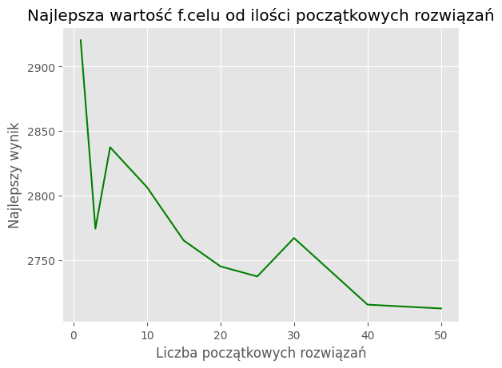

```python
plt.plot(init_solutions, best_solutions, 'g')
plt.title("Najlepsza wartość f.celu od ilości początkowych rozwiązań")
plt.xlabel("Liczba początkowych rozwiązań")
plt.ylabel("Najlepszy wynik")
```

### Złożoność czasowa

Na tym etapie badaliśmy czas wykonywania naszego algorytmu dla trzech rozmiarów problemu: małego, średniego i dużego

```python
# Przypadek mały - 1000km
car = ds.Car(TANK_CAPACITY, FUEL_CONSUM, 0, FUEL_START)
stations, _ = utils.random_station_generator(300,1000,price_range=(7,10))
init_s = init_solution(car, 1000, MAX_EXTRA_ROUTE, stations)

print(f'P = 0:')
time = %timeit -r 5 -n 10 -o simulated_annealing(new_solution,init_s, stations, 1000, MAX_EXTRA_ROUTE,0, 20000, 0.99, 10000)


print(f'P = 0.5:')
time = %timeit -r 5 -n 10 -o simulated_annealing(new_solution,init_s, stations, 1000, MAX_EXTRA_ROUTE,0.5, 20000, 0.99, 10000)

print(f'P = 1:')
time = %timeit -r 5 -n 10 -o simulated_annealing(new_solution,init_s, stations, 1000, MAX_EXTRA_ROUTE,1, 20000, 0.99, 10000)
```

```
P = 0:
203 ms ± 5.95 ms per loop (mean ± std. dev. of 5 runs, 10 loops each)
P = 0.5:
313 ms ± 17.6 ms per loop (mean ± std. dev. of 5 runs, 10 loops each)
P = 1:
478 ms ± 26.9 ms per loop (mean ± std. dev. of 5 runs, 10 loops each)
```

```python
# Przypadek średni - 5000km
car = ds.Car(TANK_CAPACITY, FUEL_CONSUM, 0, FUEL_START)
stations, _ = utils.random_station_generator(1500,5000,price_range=(7,10))
init_s = init_solution(car, 5000, MAX_EXTRA_ROUTE, stations)

print(f'P = 0:')
time = %timeit -r 5 -n 10 -o simulated_annealing(new_solution,init_s, stations, 5000, MAX_EXTRA_ROUTE,0, 20000, 0.99, 10000)


print(f'P = 0.5:')
time = %timeit -r 5 -n 10 -o simulated_annealing(new_solution,init_s, stations, 5000, MAX_EXTRA_ROUTE,0.5, 20000, 0.99, 10000)

print(f'P = 1:')
time = %timeit -r 5 -n 10 -o simulated_annealing(new_solution,init_s, stations, 5000, MAX_EXTRA_ROUTE,1, 20000, 0.99, 10000)
```

```
P = 0:
502 ms ± 14.1 ms per loop (mean ± std. dev. of 5 runs, 10 loops each)
P = 0.5:
856 ms ± 55.8 ms per loop (mean ± std. dev. of 5 runs, 10 loops each)
P = 1:
1.18 s ± 90.7 ms per loop (mean ± std. dev. of 5 runs, 10 loops each)
```

```python
# Przypadek duży - 10000km
car = ds.Car(TANK_CAPACITY, FUEL_CONSUM, 0, FUEL_START)
stations, _ = utils.random_station_generator(3000,10000,price_range=(7,10))
init_s = init_solution(car, 10000, MAX_EXTRA_ROUTE, stations)

print(f'P = 0:')
time = %timeit -r 5 -n 10 -o simulated_annealing(new_solution,init_s, stations, 10000, MAX_EXTRA_ROUTE,0, 20000, 0.99, 10000)


print(f'P = 0.5:')
time = %timeit -r 5 -n 10 -o simulated_annealing(new_solution,init_s, stations, 10000, MAX_EXTRA_ROUTE,0.5, 20000, 0.99, 10000)

print(f'P = 1:')
time = %timeit -r 5 -n 10 -o simulated_annealing(new_solution,init_s, stations, 10000, MAX_EXTRA_ROUTE,1, 20000, 0.99, 10000)
```

```
P = 0:
1.17 s ± 37.7 ms per loop (mean ± std. dev. of 5 runs, 10 loops each)
P = 0.5:
2.07 s ± 89.4 ms per loop (mean ± std. dev. of 5 runs, 10 loops each)
P = 1:
2.95 s ± 104 ms per loop (mean ± std. dev. of 5 runs, 10 loops each)
```

Oprócz oczywistych czynników jak ilość iteracji (regulowane przez paremery T, $\alpha$ oraz max_iter) czy wielkość problemu, widoczny wpływ na złożoność czasową ma wartość parametru P.

## Przypadek złośliwy dla algorytmu

Przypadek jaki spowoduje niewykonanie procedury jest przypadek gdy mamy 'dziurę' w trasie. Może dojść do sytuacji kiedy wprowadzimy zbyt mało stacji i dojechanie do kolejnej, nawet po zatankowaniu do pełna będzie niemożliwe. Program zwraca wtedy błąd i informuje uzytkownia w którym momencie nie można znaleźć kolejnej stacji.

Co możemy wtedy zrobić?

- Zwiększyć MAX_EXTRA_ROUTE
- Wprowadzić więcej stacji branych pod uwagę